# Forecasting Time Series Models: Problem Set 2

Hannah Laws

15 February, 2019

```r
library(fpp2) # You will always load this package before analyzing any time series data.
library(forecast)
```

### Question 1:

Calculate the residuals from a seasonal naive forecast applied to the quarterly Australian beer production data from 1992. The following code will help.

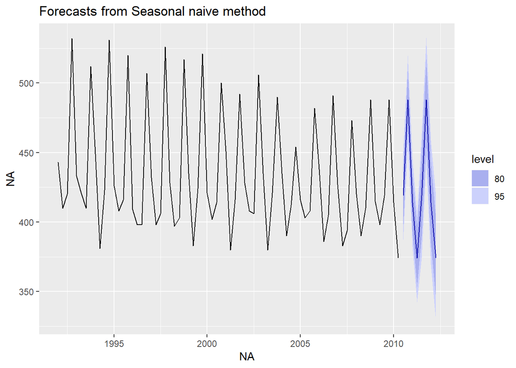

```r
beer <- window(ausbeer, start=1992)
fc_beer <- beer %>%
  snaive()

fc_beer %>%
  autoplot()
```

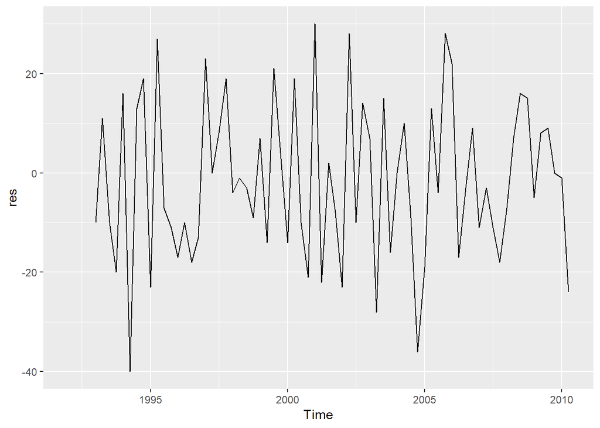

```r
res <- fc_beer %>%
  residuals()

autoplot(res)
```

Test if the residuals are white noise and normally distributed.

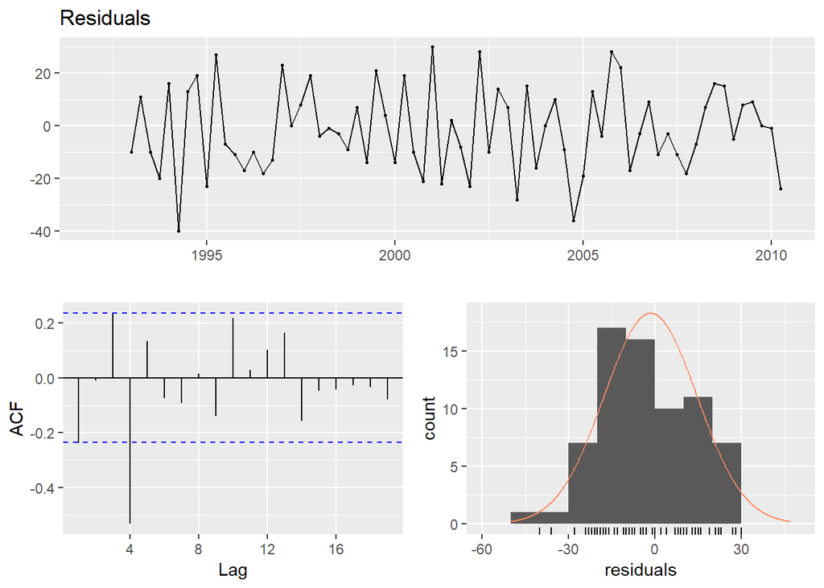

```r
# Your R code goes here
checkresiduals(res)
```

### Question 2:

Consider the daily closing IBM stock prices (data set `ibmclose`).

- What is this data about? (hint: you can use `?ibmclose`) This data is about the closing stock price of IBM taken daily.
- Produce some plots of the data in order to become familiar with it.

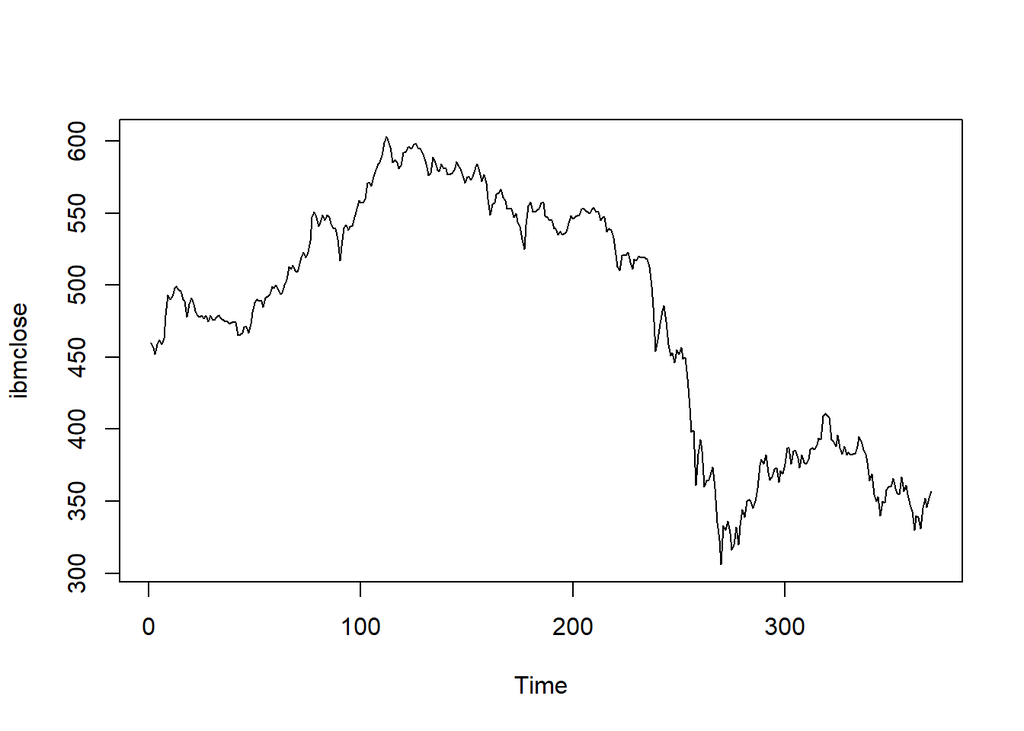

```r
plot(ibmclose)
```

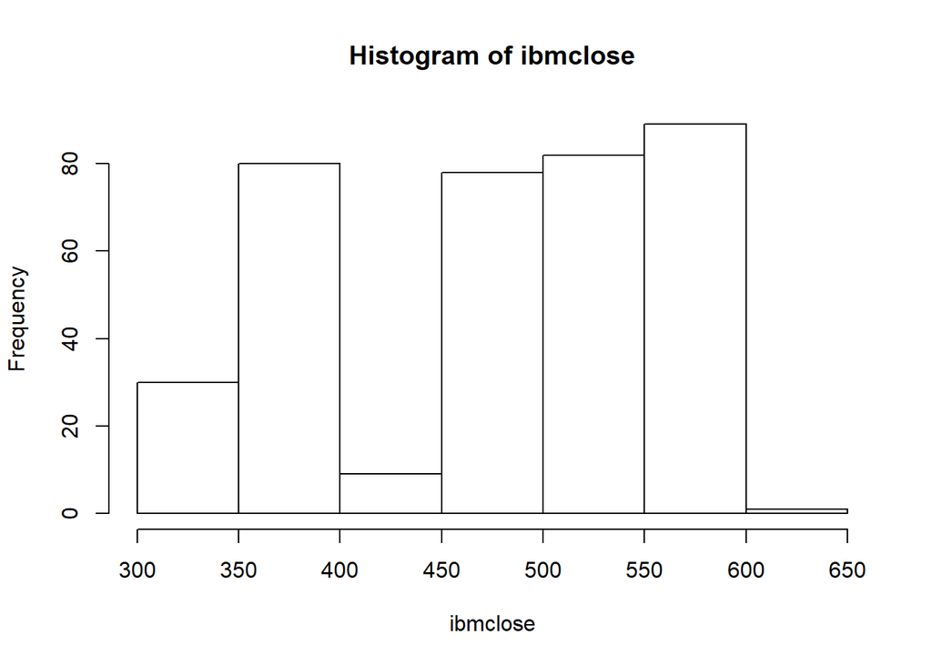

```r
hist(ibmclose)
```

- Split the data into a training set of 300 observations and a test set of 69 observations.

```r
set.seed(9)
a<-sample.int(369,size = 300)
trainset <- (ibmclose[a])
testset<-(ibmclose[-a])
```

- Try using various benchmark methods to forecast the training set and compare the results on the test set. Which method did best?

```r
avg_train<-trainset %>%
  meanf(h=69)
seas_train<-trainset %>%
  snaive(h=69)
naive_train<-trainset %>%
  naive(h=69)
drift_train<-trainset %>%
  rwf(h=69, drift = TRUE)



accuracy(avg_train,testset)
```

```
##                         ME     RMSE      MAE       MPE     MAPE     MASE
## Training set -9.090784e-15 83.41766 72.18800 -3.420567 16.32321 1.000000
## Test set     -1.450145e+00 87.03284 75.73014 -4.153341 17.50891 1.049068
```

```r
accuracy(seas_train,testset)
```

```
##                      ME     RMSE      MAE       MPE     MAPE     MASE
## Training set -0.4715719 119.9027 95.78930 -3.628856 21.30588 1.000000
## Test set     69.2898551 111.2371 99.75362 11.236656 19.97640 1.041386
##                    ACF1
## Training set -0.4907752
## Test set             NA
```

```r
accuracy(naive_train,testset)
```

```
##                      ME     RMSE      MAE       MPE     MAPE     MASE
## Training set -0.4715719 119.9027 95.78930 -3.628856 21.30588 1.000000
## Test set     69.2898551 111.2371 99.75362 11.236656 19.97640 1.041386
##                    ACF1
## Training set -0.4907752
## Test set             NA
```

```r
accuracy(drift_train,testset)
```

```
##                        ME     RMSE      MAE      MPE     MAPE     MASE
## Training set 3.813607e-16 119.9018 95.80034 -3.52693 21.29672 1.000115
## Test set     8.579487e+01 117.4189 99.74601 15.14677 19.26309 1.041306
##                    ACF1
## Training set -0.4907752
## Test set             NA
```

After testing all the benchmark methods, it would seem that average method did the best seeing that the RMSE is the lowest in both the training and test set.

- Check the residuals of your preferred method. Do they resemble white noise?

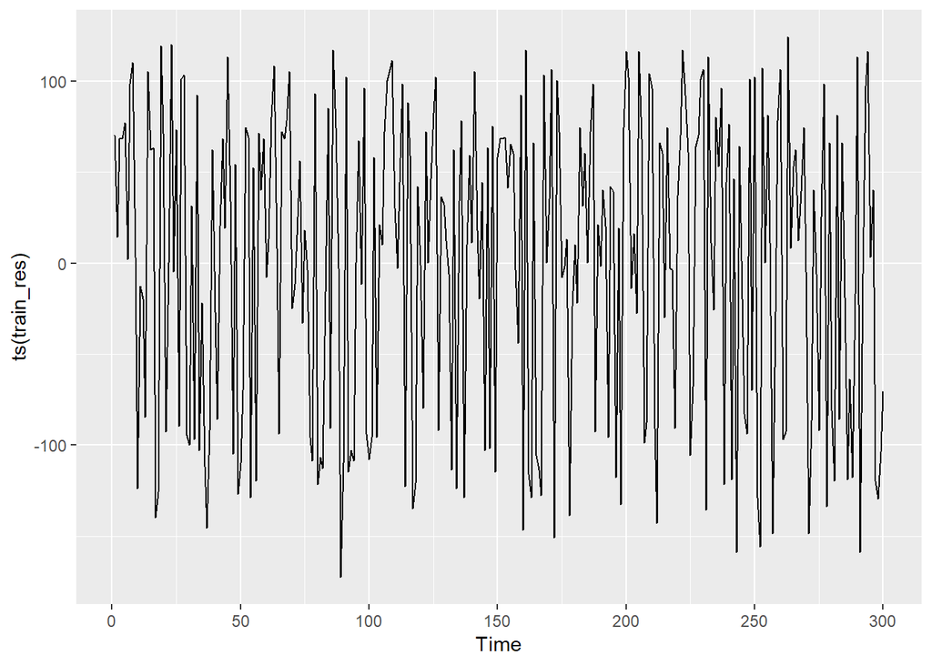

```r
train_res<-residuals(avg_train)
autoplot(ts(train_res))
```

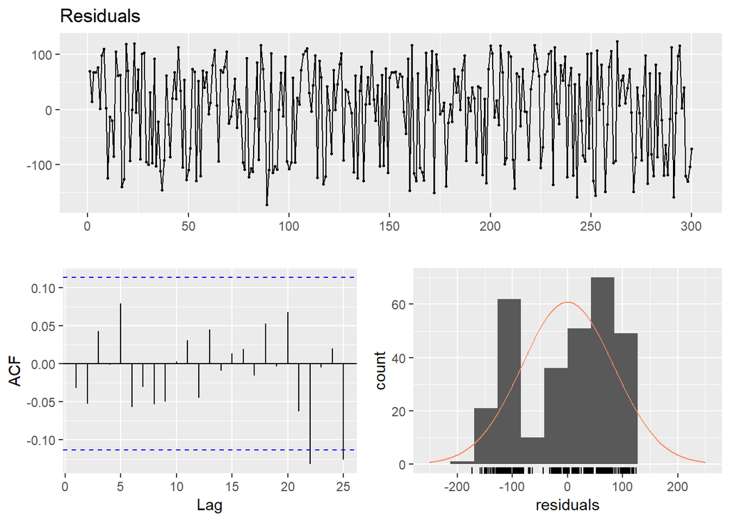

```r
checkresiduals(train_res)
```

### Question 3:

Consider the sales of new one-family houses in the USA, Jan 1973 to Nov 1995 (data set `hsales`)

- What is this data about? This data looks at the sales of new one-family houses in the USA on a monthly basis.
- Produce some plots of the data in order to become familiar with it.
- Split the `hsales` data set into a training set and a test set, where the test set is the last two years of data.

```r
train_set<-hsales[1:250]
test_set<-hsales[251:275]
```

- Try using various benchmark methods to forecast the training set and compare the results on the test set. Which method did best?

```r
avg_train<-train_set %>%
  meanf(h=25)
seas_train<-train_set %>%
  snaive(h=25)
naive_train<-train_set %>%
  naive(h=25)
drift_train<-train_set %>%
  rwf(h=25, drift = TRUE)



accuracy(avg_train,test_set)
```

```
##                         ME      RMSE      MAE       MPE     MAPE      MASE
## Training set -3.973211e-16 12.186931 9.566912 -6.168798 20.45549 1.0000000
## Test set      3.732000e+00  8.844514 7.302880  4.674728 12.81295 0.7633477
```

```r
accuracy(seas_train,test_set)
```

```
##                        ME     RMSE      MAE        MPE      MAPE     MASE
## Training set  0.004016064 6.310888 5.008032 -0.7478067  9.921034 1.000000
## Test set     -0.320000000 8.024961 6.560000 -2.7607465 12.332043 1.309896
##                   ACF1
## Training set 0.1823145
## Test set            NA
```

```r
accuracy(naive_train,test_set)
```

```
##                        ME     RMSE      MAE        MPE      MAPE     MASE
## Training set  0.004016064 6.310888 5.008032 -0.7478067  9.921034 1.000000
## Test set     -0.320000000 8.024961 6.560000 -2.7607465 12.332043 1.309896
##                   ACF1
## Training set 0.1823145
## Test set            NA
```

```r
accuracy(drift_train,test_set)
```

```
##                         ME     RMSE      MAE        MPE      MAPE     MASE
## Training set -1.640737e-15 6.310887 5.008500 -0.7560182  9.922314 1.000093
## Test set     -3.722088e-01 8.028245 6.560482 -2.8567771 12.344486 1.309992
##                   ACF1
## Training set 0.1823145
## Test set            NA
```

- Check the residuals of your preferred method. Do they resemble white noise?

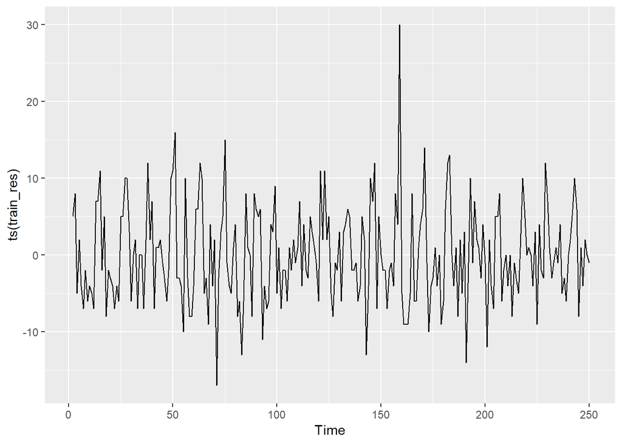

```r
train_res<-residuals(drift_train)
autoplot(ts(train_res))
```

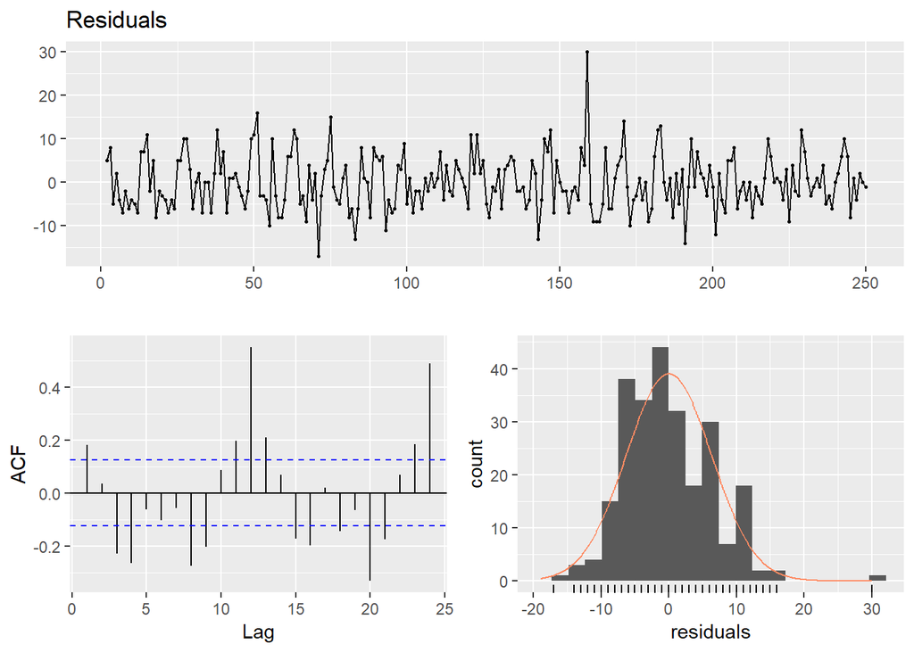

```r
checkresiduals(train_res)
```

THe residuals in the histogram look to have the shape of a normal distribution. The ACF plot also shows that the pattern in the residuals is seasonal with many of the lags peaking past the threshold. This does not seem to be white noise, so there is some information we are missing with the drift method.